# CAB220 se2 2020: Portfolio 2

Due 11:59pm Sunday 27 September 2020

# About this Assessment item

This individual Assessment item accounts for 20% of your overall grade of CAB220 and aims to assess your knowledge and skills in

- Following clear instructions
- Summarizing data
- Statistical hypothesis testing
- Exploratory data analysis
- Linear regression
- Logistic regression
- Using `R` for data science, as described in
  - [R for Data Science](https://r4ds.had.co.nz/) by Garrett Grolemund and Hadley Wickham
  - [ggplot2: Elegant Graphics for Data Analysis](https://ggplot2-book.org/) by Hadley Wickham

While every attempt has been made to present this Assessment clearly and correctly we may update this Assessment item with additional points of clarification or correction.

- Any such changes will be announced on BlackBoard.

## How to submit this Assessment item

In the following instructions, replace the string `10212361` with your 7 or 8 digit student number so the Teaching Team can identify your submission.

1. Complete the assessment by writing `R` and `Rmarkdown` code below the “Assessment Tasks” heading to solve these tasks
2. Replace the text on line 3 `put your student number and name here` with your student number and name
3. Rename the file containing your completed submission `CAB220_20se2_Portfolio2_n10212361.Rmd`
4. Knit your submission into `.html` output,  
   open that output in your web browser and  
   save it in PDF format to the file `CAB220_20se2_Portfolio2_n10212361.pdf`
   - If you prefer, you can knit your submission directly to PDF but you will need $\LaTeX$ installed to do that
5. Zip both the `.Rmd` and `.pdf` you have created into a file called `CAB220_20se2_Portfolio2_n10212361.zip`
6. Submit your `.zip` file using the submission link in **Blackboard > Assessment > Portfolio 2**

**Make sure that you understand and can execute these steps well before the due date.**

## About the data

The fictitious data set for this Assessment consists of observations of first-year University students with variables *case ID*, *Attrition*, *Degree Type*, *Achieved Credit Points*, *Attendance Type*, *Age*, *Failed Credit Points*, *International student*, *First in family in university*, *Gender*, *GPA*, *OP Score*, *Socio Economic Status*, *Teaching Period Admitted*, and *Faculty*.

- This dataset is provided in `./data/students.csv`

## About the tasks and their marks

There are 7 Tasks worth marks as follows:

| Task | Marks |
| --- | --- |
| Task 1: Following clear instructions | 1 |
| Task 2: Summarizing data | 5 |
| Task 3: Statistical hypothesis testing | 2 |
| Task 4: Exploratory data analysis | 2 |
| Task 5: Linear regression | 5 |
| Task 6: Logistic regression | 4 |
| Task 7: Using `R` for data science | 1 |

# The Assessment tasks

## Task 1: Follow the instructions

1. Submit your work according to the instructions in the “How to submit this Assessment item” section

## Task 2: Summarizing data

2. Appropriately summarise each variable (except *case ID*) using tables and/or graphs

```r
data <- read_csv("./data/students.csv")
summary(data[c(4,6,7,11,12)])
```

```
##  Achieved_Credit_Points      Age        Failed_Credit_Points      GPA
##  Min.   :  0.00         Min.   :18.00   Min.   :  0.00       Min.   :0.000
##  1st Qu.: 60.00         1st Qu.:19.00   1st Qu.:  0.00       1st Qu.:4.120
##  Median : 96.00         Median :20.00   Median :  0.00       Median :4.880
##  Mean   : 92.88         Mean   :22.72   Mean   :  7.98       Mean   :4.546
##  3rd Qu.:108.00         3rd Qu.:23.00   3rd Qu.: 12.00       3rd Qu.:5.620
##  Max.   :372.00         Max.   :86.00   Max.   :108.00       Max.   :7.000
##     OP_Score
##  Min.   : 1.00
##  1st Qu.: 6.00
##  Median : 9.50
##  Mean   :10.76
##  3rd Qu.:15.00
##  Max.   :25.00
```

```r
table(data$Attrition)
```

```
##
## Not Retained     Retained
##          539         2461
```

```r
table(data$Degree_Type)
```

```
##
## Double Single
##    204   2796
```

```r
table(data$Attendance_Type)
```

```
##
## Full Time Part Time
##      2716       284
```

```r
table(data$International_student)
```

```
##
##   No  Yes
## 2627  373
```

```r
table(data$First_in_family)
```

```
##
##   No  Yes
## 1850 1150
```

```r
table(data$Gender)
```

```
##
##    F    M
## 1473 1527
```

```r
table(data$Socio_Economic_Status)
```

```
##
##   High    Low Medium
##    889    557   1554
```

```r
table(data$Teaching_Period_Admitted)
```

```
##
## SEM-1 SEM-2
##  2479   521
```

```r
table(data$Faculty)
```

```
##
##           CI Faculty Faculty of Education    Faculty of Health
##                  507                  186                  794
##       Faculty of Law  QUT Business School  Sci and Eng Faculty
##                  284                  452                  777
```

## Task 3: Statistical hypothesis testing

3. Compare average GPA between male and female students using an informative graph and an appropriate statistical test.  
   Interpret your findings.

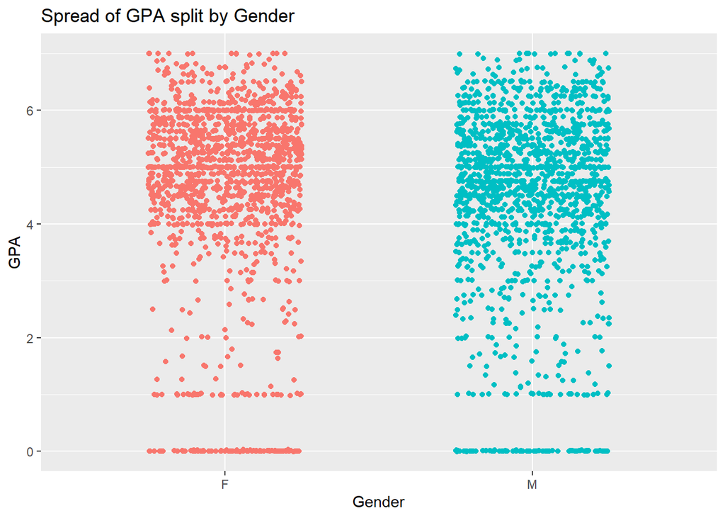

```r
ggplot(data=data, aes(x=Gender, y=GPA)) +
  geom_jitter(aes(color=Gender), width=0.25) +
  theme(legend.position="none") +
  labs(title = "Spread of GPA split by Gender")
```

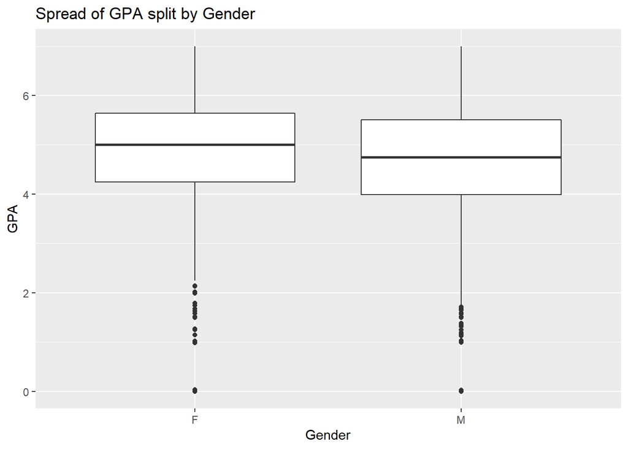

```r
ggplot(data=data, aes(x = Gender, y = GPA)) +
  geom_boxplot() +
  theme(legend.position="none") +
  labs(title = "Spread of GPA split by Gender")
```

> Females tend to have a slightly higher GPA than Males

## Task 4: Exploratory data analysis

4. Explore the relationship between OP Score and GPA using a graph.  
   Describe the relationship.

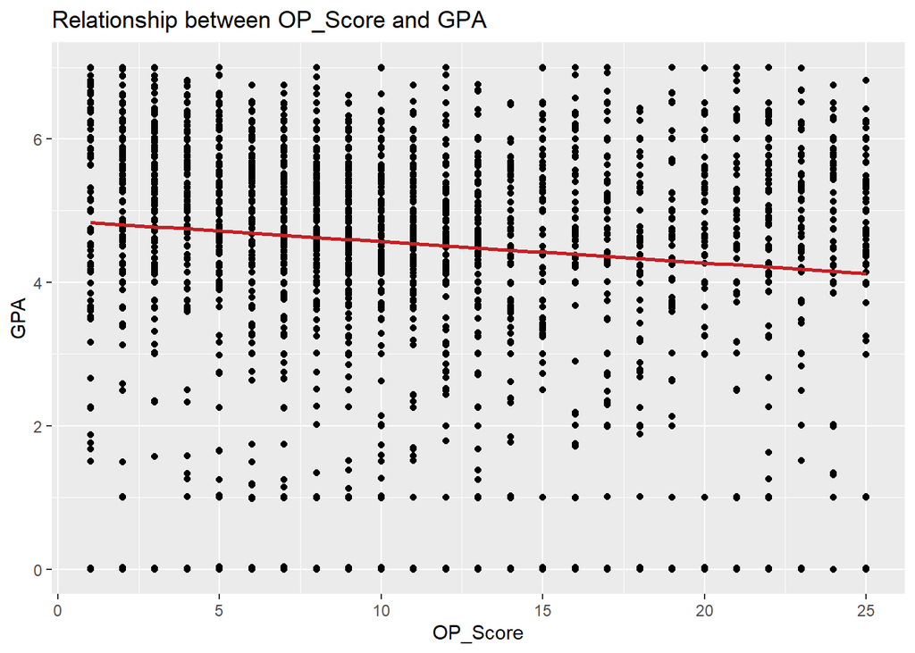

```r
ggplot(data, aes(x = OP_Score, y = GPA)) +
   geom_point() +
    stat_smooth(method = "lm",
        col = "#C42126",
        se = FALSE,
        size = 1) +
  theme(legend.position="none") +
  labs(title = "Relationship between OP_Score and GPA")
```

## Task 5: Linear regression

5. Develop a linear regression model of GPA using the given data.  
   Describe your choice of predictors, examine your model’s assumptions, assess model fit, and interpret the final model’s regression coefficients.

## Task 6: Logistic regression

6. Develop a logistic regression model to predict Attrition.  
   Describe your choice of predictors, assess model fit, and interpret the final model’s regression coefficients.

## Task 7: Using `R` for data science

7. In completing this Assessment, use the principles and approaches espoused in [R for Data Science](https://r4ds.had.co.nz/) by Garrett Grolemund and Hadley Wickham to ensure that your work can be run, reproduced and understood by the Teaching Team.